# Starter Code For NHTS Analysis

Carole Voulgaris

11/19/2020

## Introduction

The purpose of this document is demonstrate some methods that will be useful to load data from the National Household Travel Survey (NHTS), apply survey weights, calculate descriptive statistics, and generate informative tables.

## Load libraries

We’ll be using the following libraries for this analysis.

```r
library(tidyverse)
library(survey)
library(srvyr)
library(treemapify)
library(knitr)
library(jtools)
library(interactions)
```

## Load NHTS Data

I’ve already downloaded the NHTS 2017 csv files from https://nhts.ornl.gov/ and extracted the contents to a folder called “NHTS_data” in my project directory.

There are four data files included in my NHTS_data folder now.

- The household file (hhpub.csv) includes household-level data
- The person file (perpub.csv) includes person-level data
- The trip file (trippub.csv) includes trip-level data
- The vehicle file (vehpub.csv) includes vehicle-level data

The NHTS_data folder is not included in this repo (it’s listed in the .gitignore file), so you’ll need to create that folder in your local working directory, download the data files, and save them there.

You can find a list of the variables in each of these files in the [2017 NHTS Codebook](https://nhts.ornl.gov/assets/codebook_v1.2.pdf).

For the first part of this example, I’ll do a household-level analysis to estimate the likelihood that a vehicle-owning household owns an electric vehicle, based on household income, the presence of a BIPOC in the household, and the average commute time to work among household workers.

I’ll need to load or derive the following variables:

- Household survey weight
  - Used to calculate descriptive statistics
  - WTHHFIN in hhpub.csv
- Household ID
  - Used to join variables from different files
  - HOUSEID in all files
- Presence of a household vehicle
  - Binary variable used to define the sample
  - Derived from HHVEHCNT in the hhpub.csv
- Household income
  - Independent continuous variable
  - Derived from HHFAMINC in hhpub.csv
- Presence of an electric vehicle
  - Dependent binary variable
  - Derived from HFUEL in vehpub.csv
- Presence of a BIPOC in the household
  - Independent binary variable
  - Derived from R_HISP and R_RACE in perpub.csv
- Average commute time to work among household workers
  - Independent continuous variable
  - Derived from NOCONG in perpub.csv

### Load variables from the household file

We’ll need four variables from the household file:

- `HOUSEID`
- `HHVEHCNT`
- `HHFAMINC`
- `WTHHFIN`

I’ll create a binary variable called `has_veh` from HHVEHCNT to indicate whether the household has any vehicles, and I’ll create a continuous variable called `income_k` indicating the household income in thousands, based on the midpoints of the categories in the categorical `HHFAMINC` variable. Once I’ve created those new variables, I’ll drop the variables I used to derive them, and I’ll also drop the rows for households that don’t own any vehicles.

```r
hhs <- read_csv("NHTS_data/hhpub.csv") %>%
  select(HOUSEID, HHVEHCNT, HHFAMINC, WTHHFIN) %>%
  mutate(income_k = case_when(HHFAMINC == "01" ~ 5,
                              HHFAMINC == "02" ~ 12.5,
                              HHFAMINC == "03" ~ 20,
                              HHFAMINC == "04" ~ 30,
                              HHFAMINC == "05" ~ 42.5,
                              HHFAMINC == "06" ~ 62.5,
                              HHFAMINC == "07" ~ 87.5,
                              HHFAMINC == "08" ~ 112.5,
                              HHFAMINC == "09" ~ 137.5,
                              HHFAMINC == "10" ~ 175,
                              HHFAMINC == "11" ~ 250,
                              TRUE ~ -1)) %>%
  mutate(has_veh = HHVEHCNT > 0) %>%
  select(HOUSEID, has_veh, income_k, WTHHFIN) %>%
  filter(has_veh)
```

### Load variables from vehicle file

The only variables I need from the vehicle file are `HOUSEID` and `HFUEL`. I’ll use `HFUEL` to create a binary variable called `is_ev` indicating whether a vehicle is fully electric. Then I’ll use `group_by()` and `summarize()` to collapse the dataset to the household level, with a variable called `has_ev` indicating whether any of the vehicles in a household are electric.

Then, I’ll add those variables to the household file.

```r
vehs <- read_csv("NHTS_data/vehpub.csv") %>%
  select(HOUSEID, HFUEL) %>%
  mutate(is_ev = (HFUEL == "03")) %>%
  group_by(HOUSEID) %>%
  summarize(has_ev = max(is_ev))

hhs <- hhs %>%
  left_join(vehs)
```

### Load variables from person file

- `HOUSEID`
- `R_RACE`
- `R_HISP`
- `NOCONG`

I’ll use R_RACE and R_HISP to create a binary variable indicating whether the person is non-Hispanic white.

`NOCONG` indicates the travel time to work (without traffic), but only for those who commute by private vehicle. To get an average of those, I’ll create a second dataframe called `drive_ppl` that only includes those with a value for this variable (i.e. who commute to work in a car), and take the average within each household for that dataset.

Finally, I’ll add those variables to the household file.

```r
ppl <- read_csv("NHTS_data/perpub.csv") %>%
  select(HOUSEID, R_RACE, R_HISP, WRKTRANS, NOCONG) %>%
  mutate(is_nh_white = (R_RACE == "01" & R_HISP == "02")) %>%
  group_by(HOUSEID)

drive_ppl <- ppl %>%
  filter(NOCONG > 0) %>%
  summarize(avg_commute = mean(NOCONG))

ppl <- ppl %>%
  summarize(has_BIPOC = !as.logical(min(is_nh_white))) %>%
  left_join(drive_ppl) %>%
  mutate(avg_commute = replace_na(avg_commute, 0))

hhs <- hhs %>%
  left_join(ppl)
```

## Descriptive statistics

Before running your regression, you may find it helpful to generate some descriptive statistics. I’m not doing that here in this example, but you can refer to NHTS_starter.html for some useful methods.

### Apply weights

Be sure and apply survey weights before calculating descriptive statistics.

### Percent of households with electric vehicles

Try calculating the percentage of U.S. households that own an electrici vehicle.

## Regression

Let’s predict the likelihood that a vehicle-owning household will own an electric vehicle, based on income, the presence of a BIPOC in the household, and the average time household workers commute in a car.

```r
model1 <- glm(has_ev ~ income_k + has_BIPOC + avg_commute,
              data = hhs, family = "binomial")

summary(model1)
```

```
##
## Call:
## glm(formula = has_ev ~ income_k + has_BIPOC + avg_commute, family = "binomial",
##     data = hhs)
##
## Deviance Residuals:
##     Min       1Q   Median       3Q      Max
## -0.2471  -0.0965  -0.0719  -0.0611   3.6733
##
## Coefficients:
##                 Estimate Std. Error z value Pr(>|z|)
## (Intercept)   -6.7172207  0.0914441 -73.457   <2e-16 ***
## income_k       0.0121603  0.0005044  24.106   <2e-16 ***
## has_BIPOCTRUE  0.2031338  0.0934173   2.174   0.0297 *
## avg_commute   -0.0008957  0.0027598  -0.325   0.7455
## ---
## Signif. codes:  0 '***' 0.001 '**' 0.01 '*' 0.05 '.' 0.1 ' ' 1
##
## (Dispersion parameter for binomial family taken to be 1)
##
##     Null deviance: 7364.8  on 123446  degrees of freedom
## Residual deviance: 6830.4  on 123443  degrees of freedom
## AIC: 6838.4
##
## Number of Fisher Scoring iterations: 8
```

The effects of income are often logrithmic (i.e. changes happen with percentage increases rather than without absolute increases). Let’s see if a log-transformation improves model fit.

```r
model2 <- glm(has_ev ~ log(income_k) + has_BIPOC + avg_commute,
              data = hhs, family = "binomial")
summary(model2)
```

```
##
## Call:
## glm(formula = has_ev ~ log(income_k) + has_BIPOC + avg_commute,
##     family = "binomial", data = hhs)
##
## Deviance Residuals:
##     Min       1Q   Median       3Q      Max
## -0.2235  -0.1118  -0.0759  -0.0495   4.3342
##
## Coefficients:
##                 Estimate Std. Error z value Pr(>|z|)
## (Intercept)   -11.650888   0.334873 -34.792   <2e-16 ***
## log(income_k)   1.403283   0.069292  20.252   <2e-16 ***
## has_BIPOCTRUE   0.225082   0.094493   2.382   0.0172 *
## avg_commute    -0.003305   0.002900  -1.140   0.2543
## ---
## Signif. codes:  0 '***' 0.001 '**' 0.01 '*' 0.05 '.' 0.1 ' ' 1
##
## (Dispersion parameter for binomial family taken to be 1)
##
##     Null deviance: 7187.4  on 119404  degrees of freedom
## Residual deviance: 6657.1  on 119401  degrees of freedom
##   (4042 observations deleted due to missingness)
## AIC: 6665.1
##
## Number of Fisher Scoring iterations: 9
```

Also, I wonder if the effect of income on EV ownership depends on whether there is at least one BIPOC in the household.

```r
model3 <- glm(has_ev ~ log(income_k) + has_BIPOC + avg_commute +
                log(income_k):has_BIPOC,
              data = hhs, family = "binomial")
summary(model3)
```

```
##
## Call:
## glm(formula = has_ev ~ log(income_k) + has_BIPOC + avg_commute +
##     log(income_k):has_BIPOC, family = "binomial", data = hhs)
##
## Deviance Residuals:
##     Min       1Q   Median       3Q      Max
## -0.2432  -0.1122  -0.0776  -0.0485   4.4874
##
## Coefficients:
##                               Estimate Std. Error z value Pr(>|z|)
## (Intercept)                 -11.187933   0.385670 -29.009   <2e-16 ***
## log(income_k)                 1.306599   0.080527  16.226   <2e-16 ***
## has_BIPOCTRUE                -1.466301   0.772409  -1.898   0.0577 .
## avg_commute                  -0.003224   0.002899  -1.112   0.2660
## log(income_k):has_BIPOCTRUE   0.350210   0.157750   2.220   0.0264 *
## ---
## Signif. codes:  0 '***' 0.001 '**' 0.01 '*' 0.05 '.' 0.1 ' ' 1
##
## (Dispersion parameter for binomial family taken to be 1)
##
##     Null deviance: 7187.4  on 119404  degrees of freedom
## Residual deviance: 6652.0  on 119400  degrees of freedom
##   (4042 observations deleted due to missingness)
## AIC: 6662
##
## Number of Fisher Scoring iterations: 9
```

Let’s show the results of those three alternative models in a single table:

```r
coef_names <- c("Income (thousands)" = "income_k",
                "Income (log-transformed)" = "log(income_k)",
                "Presence of BIPOC in household" =
                  "has_BIPOCTRUE",
                "Average driving commute" = "avg_commute",
                "Interaction: income and BIPOC" = "log(income_k):has_BIPOCTRUE",
                "Constant" = "(Intercept)")

export_summs(model1, model2, model3, coefs = coef_names)
```

|  | Model 1 | Model 2 | Model 3 |
| --- | --- | --- | --- |
| Income (thousands) | 0.01 *** |  |  |
|  | (0.00) |  |  |
| Income (log-transformed) |  | 1.40 *** | 1.31 *** |
|  |  | (0.07) | (0.08) |
| Presence of BIPOC in household | 0.20 * | 0.23 * | -1.47 |
|  | (0.09) | (0.09) | (0.77) |
| Average driving commute | -0.00 | -0.00 | -0.00 |
|  | (0.00) | (0.00) | (0.00) |
| Interaction: income and BIPOC |  |  | 0.35 * |
|  |  |  | (0.16) |
| Constant | -6.72 *** | -11.65 *** | -11.19 *** |
|  | (0.09) | (0.33) | (0.39) |
| N | 123447 | 119405 | 119405 |
| AIC | 6838.43 | 6665.08 | 6662.00 |
| BIC | 6877.32 | 6703.85 | 6710.45 |
| Pseudo R2 | 0.07 | 0.08 | 0.08 |
| *** p < 0.001; ** p < 0.01; * p < 0.05. |  |  |  |

Now let’s see how the probability of owning an electric vehicle changes with with income, for households with and without BIPOC.

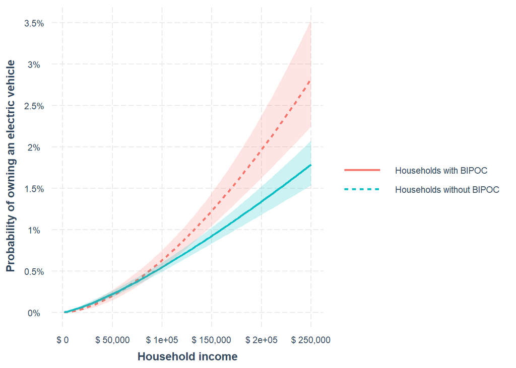

```r
interact_plot(model3, pred = "income_k", modx = "has_BIPOC", interval = TRUE) +
  scale_y_continuous(name = "Probability of owning an electric vehicle",
                     breaks = breaks <- seq(0, 0.04, by = 0.005),
                     labels = paste(breaks * 100, "%", sep = "")) +
  scale_x_continuous(name = "Household income",
                     breaks= breaks <- seq(0, 250, by = 50),
                     labels = paste("$", prettyNum(breaks*1000, big.mark = ","))) +
  scale_fill_discrete(name = "",
                      labels = c("Households with BIPOC",
                                 "Households without BIPOC")) +
  scale_color_discrete(name = "",
                      labels = c("Households with BIPOC",
                                 "Households without BIPOC")) +
  scale_linetype_discrete(name = "",
                      labels = c("Households with BIPOC",
                                 "Households without BIPOC"))
```